# hw9

Charles Yang

11/10/2021

```r
spam = read.csv('spambase.data', header = FALSE)
spam$V58 = as_factor(spam$V58)
```

```r
sum(spam$V58==1)/nrow(spam)
sum(spam$V58==0)/nrow(spam)
```

```r
# 4b
trainIndex = createDataPartition(spam$V58, p = .60, list = FALSE)
train = spam[trainIndex,]
test = spam[-trainIndex,]
print("Train spam proportion")
```

```
## [1] "Train spam proportion"
```

```r
sum(train$V58==1)/nrow(train)
```

```
## [1] 0.3940601
```

```r
print("Test spam proportion")
```

```
## [1] "Test spam proportion"
```

```r
sum(test$V58==1)/nrow(test)
```

```
## [1] 0.3940217
```

```r
glm.fit = glm(V58~., data = train, family='binomial')
glm.prob = predict(glm.fit, test, type='response')


glm.pred = rep(0, nrow(test))
glm.pred[glm.prob > 0.5] = 1

tab = table(glm.pred, test$V58)

tab
```

```
##
## glm.pred    0    1
##        0 1059   68
##        1   56  657
```

```r
1 - sum(diag(tab)) / sum(tab) # Misclassification rate
```

```
## [1] 0.0673913
```

```r
tab[2, 1] /sum(tab) # False positive
```

```
## [1] 0.03043478
```

```r
tab[1, 2]/sum(tab) # False negative
```

```
## [1] 0.03695652
```

```r
# new threshold
glm.pred = rep(0, nrow(test))
glm.pred[glm.prob > 0.55] = 1

tab = table(glm.pred, test$V58)

tab
```

```
##
## glm.pred    0    1
##        0 1072   79
##        1   43  646
```

```r
1 - sum(diag(tab)) / sum(tab) # Misclassification rate
```

```
## [1] 0.06630435
```

```r
tab[2, 1] /sum(tab) # False positive
```

```
## [1] 0.02336957
```

```r
tab[1, 2]/sum(tab) # False negative
```

```
## [1] 0.04293478
```

```r
ROCRpred = prediction(glm.prob, test$V58)
perf = performance(ROCRpred,'tpr','fpr')
```

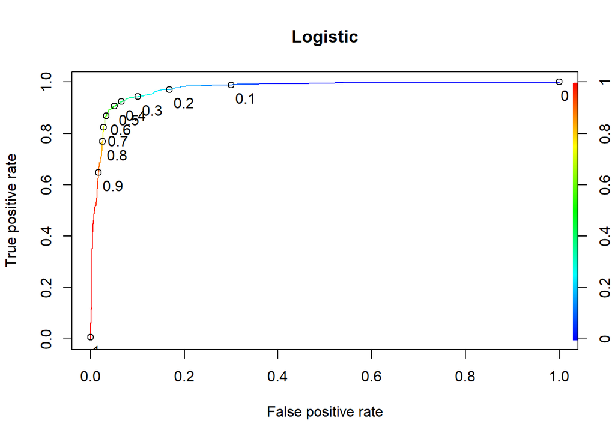

```r
plot(perf,
  colorize = TRUE,
  print.cutoffs.at = seq(0, 1, by = 0.1),
  text.adj = c(-0.2, 1.7),
  main = "Logistic")
```

```r
lda.fit = lda(V58~., data = train)

lda.prob = predict(lda.fit, test, type = "response")$posterior[, 2]
lda.pred = rep(0, nrow(test))
lda.pred[lda.prob > 0.5] <- 1

tab = table(lda.pred, test$V58)

tab
```

```
##
## lda.pred    0    1
##        0 1063  138
##        1   52  587
```

```r
1 - sum(diag(tab)) / sum(tab) # Misclassification rate
```

```
## [1] 0.1032609
```

```r
tab[2, 1] / sum(tab) # False positive
```

```
## [1] 0.02826087
```

```r
tab[1, 2] / sum(tab) # False negative
```

```
## [1] 0.075
```

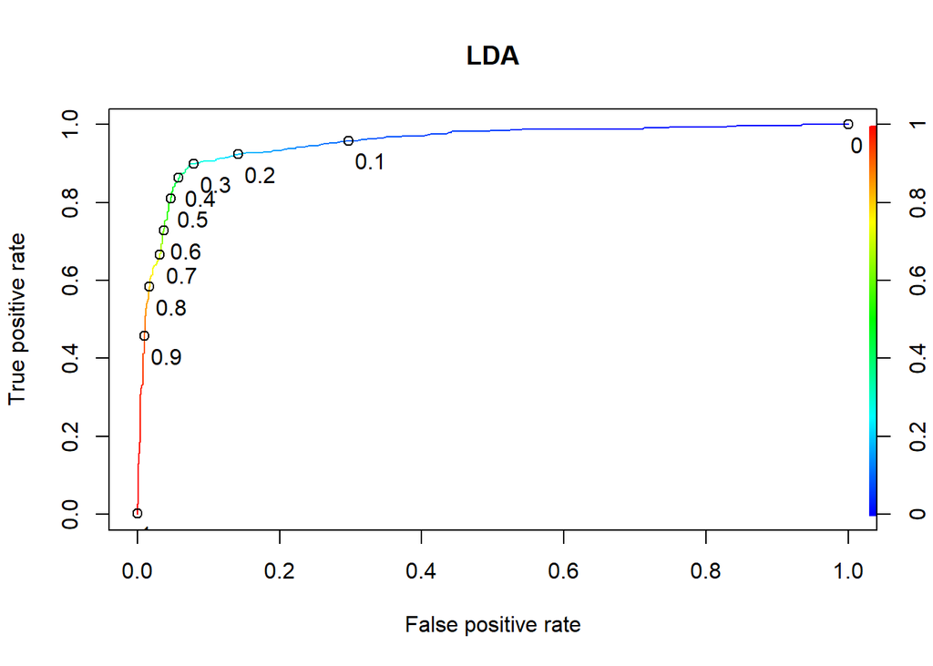

```r
ROCRpred <- prediction(lda.prob, test$V58)
plot(performance(ROCRpred, "tpr", "fpr"),
  colorize = TRUE,
  print.cutoffs.at = seq(0, 1, by = 0.1),
  text.adj = c(-0.2, 1.7),
  main = "LDA")
```

1. ROC with Spam

a. Reporting a meaningful email as spam, a false positive, is a more critical mistake. It's okay if some spam gets through, but a job offer in spam would be awful.

b. See ROC Curve above.

c. False positive: 0.03043478; False negative: 0.03695652

d. Threshold adjusted to 0.55, giving a new false positive rate of 0.02337

e. False positive: 0.02826087; False negative: 0.075  
Threshold does not need to be adjusted as fpr is already under 0.03  
If fpr needed to be reduced, I would increase the threshold, I.E. prob > 0.55

```r
# 2a
trainIndex = sample(1:nrow(OJ), 800, replace = FALSE)
train = OJ[trainIndex,]
test = OJ[-trainIndex,]
```

```r
# 2b-d
tree.OJ = tree(Purchase~., data=train)
summary(tree.OJ)
```

```
##
## Classification tree:
## tree(formula = Purchase ~ ., data = train)
## Variables actually used in tree construction:
## [1] "LoyalCH"   "PriceDiff"
## Number of terminal nodes:  8
## Residual mean deviance:  0.7577 = 600.1 / 792
## Misclassification error rate: 0.1662 = 133 / 800
```

```r
tree.OJ
```

```
## node), split, n, deviance, yval, (yprob)
##       * denotes terminal node
##
##  1) root 800 1071.00 CH ( 0.60875 0.39125 )
##    2) LoyalCH < 0.5036 346  406.70 MM ( 0.27457 0.72543 )
##      4) LoyalCH < 0.275386 172  131.50 MM ( 0.12791 0.87209 )
##        8) LoyalCH < 0.0356415 60   10.17 MM ( 0.01667 0.98333 ) *
##        9) LoyalCH > 0.0356415 112  108.10 MM ( 0.18750 0.81250 ) *
##      5) LoyalCH > 0.275386 174  236.70 MM ( 0.41954 0.58046 )
##       10) PriceDiff < 0.05 77   81.30 MM ( 0.22078 0.77922 ) *
##       11) PriceDiff > 0.05 97  132.10 CH ( 0.57732 0.42268 ) *
##    3) LoyalCH > 0.5036 454  362.00 CH ( 0.86344 0.13656 )
##      6) LoyalCH < 0.764572 186  220.40 CH ( 0.72043 0.27957 )
##       12) PriceDiff < 0.265 113  152.70 CH ( 0.59292 0.40708 )
##         24) PriceDiff < -0.35 15   15.01 MM ( 0.20000 0.80000 ) *
##         25) PriceDiff > -0.35 98  126.50 CH ( 0.65306 0.34694 ) *
##       13) PriceDiff > 0.265 73   41.48 CH ( 0.91781 0.08219 ) *
##      7) LoyalCH > 0.764572 268   85.39 CH ( 0.96269 0.03731 ) *
```

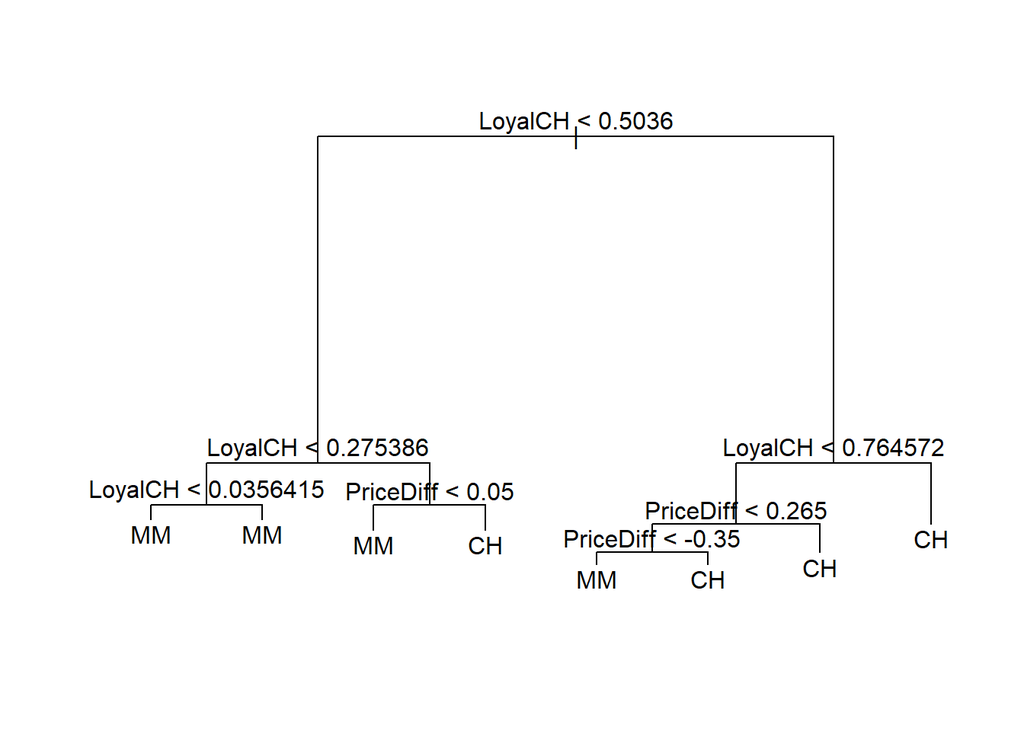

```r
plot(tree.OJ)
text(tree.OJ,pretty=0)
```

2. Decision Tree with OJ

a. See code above.

b. We get 8 terminal nodes and a training misclassiciation error of 0.1662.

c. Interpreting node 8:  
An observation with LoyalCH < 0.03564 will be marked as a Minute Made purchase.

d. The tree has 7 decision branches and 8 regions.

```r
tree.prob = predict(tree.OJ, newdata=test)[, 2]

tree.pred = rep(1, nrow(test))
tree.pred[tree.prob > 0.5] = 2

tab = table(tree.pred, test$Purchase)
tab
```

```
##
## tree.pred  CH  MM
##         1 155  33
##         2  11  71
```

```r
1 - sum(diag(tab)) / sum(tab)
```

```
## [1] 0.162963
```

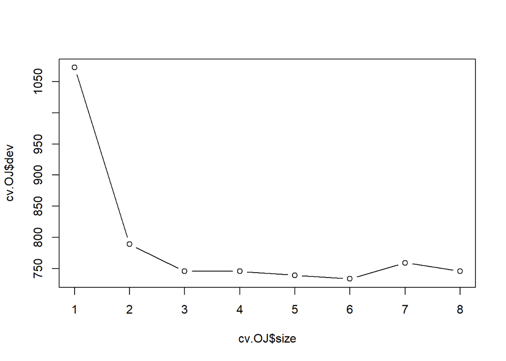

```r
cv.OJ = cv.tree(tree.OJ) #performs CV in on order to the determine the optimal level of tree complexity.
plot(cv.OJ$size, cv.OJ$dev, type='b') # plot CV error as a function of size of tree
```

```r
prune.OJ= prune.tree(tree.OJ, best=6) #best represents the size of a specific subtree in the cost-complexity sequence to be returned
summary(prune.OJ)
```

```
##
## Classification tree:
## snip.tree(tree = tree.OJ, nodes = c(12L, 4L))
## Variables actually used in tree construction:
## [1] "LoyalCH"   "PriceDiff"
## Number of terminal nodes:  6
## Residual mean deviance:  0.7866 = 624.6 / 794
## Misclassification error rate: 0.1775 = 142 / 800
```

```r
prune.prob = predict(prune.OJ, newdata=test)[, 2]

prune.pred = rep(1, nrow(test))
prune.pred[prune.prob > 0.5] = 2

tab = table(prune.pred, test$Purchase)
tab
```

```
##
## prune.pred  CH  MM
##          1 156  39
##          2  10  65
```

```r
1 - sum(diag(tab)) / sum(tab)
```

```
## [1] 0.1814815
```

2. Decision Tree with OJ (Continued)

e. See output above for confusion matrix. Misclassification rate of 0.162963

f+g. See plot above. The optimal tree size is 6.

h. See code above.

i. Unpruned MSE: 0.1662; Pruned MSE: 0.1775  
The higher training error in the pruned tree is expected because pruning reduces the flexibility of the tree, which worsens the fit to the training data.

j. Unpruned test MSE: 0.162963; Pruned test MSE: 0.1814815  
I thought that the pruned tree would have a better test MSE, but apparently not. This could either be due to random chance, or it was over-pruned.

3. Concept Review

a.

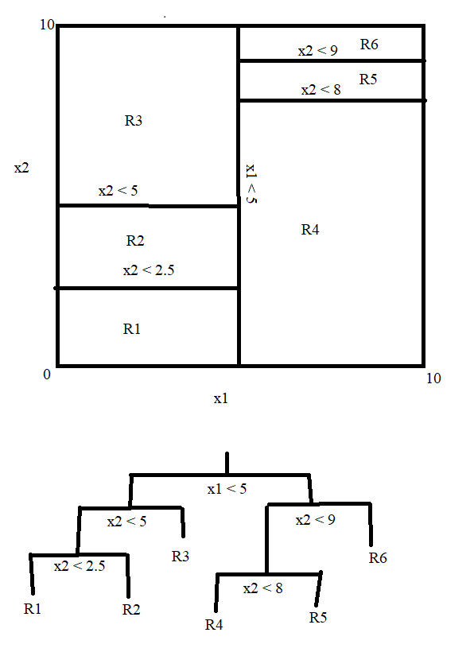

b.

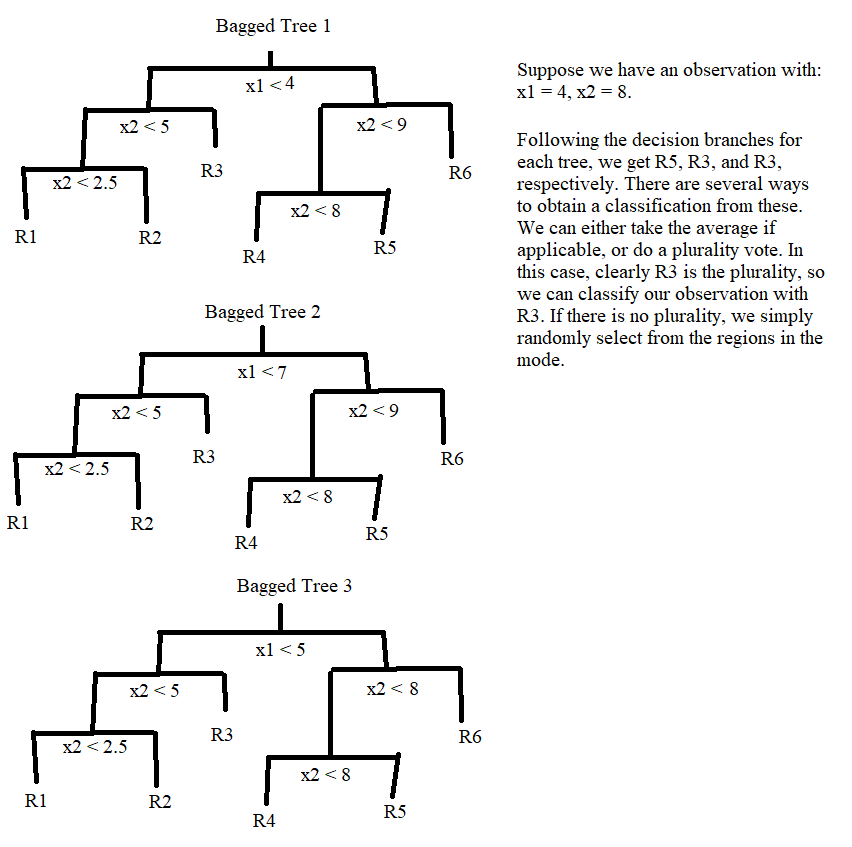

c. 0.1, 0.15, 0.2, 0.2, 0.55, 0.6, 0.6, 0.65, 0.7, 0.75.  
Majority Vote: G, G, G, G, R, R, R, R, R, R = Red  
Average Prob. = 0.45 = Green  
They're different!